# St_4_[24]

# Introduction

The `mtcars` dataset contains information about various attributes of 32 different car models. This analysis aims to investigate the relationship between transmission type and fuel efficiency (mpg), considering other variables as well. We’ll start by exploring the dataset and then perform linear regression analysis.

# Dataset Exploration

```r
data(mtcars)
str(mtcars)
```

```
'data.frame':   32 obs. of  11 variables:
 $ mpg : num  21 21 22.8 21.4 18.7 18.1 14.3 24.4 22.8 19.2 ...
 $ cyl : num  6 6 4 6 8 6 8 4 4 6 ...
 $ disp: num  160 160 108 258 360 ...
 $ hp  : num  110 110 93 110 175 105 245 62 95 123 ...
 $ drat: num  3.9 3.9 3.85 3.08 3.15 2.76 3.21 3.69 3.92 3.92 ...
 $ wt  : num  2.62 2.88 2.32 3.21 3.44 ...
 $ qsec: num  16.5 17 18.6 19.4 17 ...
 $ vs  : num  0 0 1 1 0 1 0 1 1 1 ...
 $ am  : num  1 1 1 0 0 0 0 0 0 0 ...
 $ gear: num  4 4 4 3 3 3 3 4 4 4 ...
 $ carb: num  4 4 1 1 2 1 4 2 2 4 ...
```

```r
summary(mtcars)
```

```
      mpg             cyl             disp             hp             drat             wt             qsec             vs               am              gear
 Min.   :10.40   Min.   :4.000   Min.   : 71.1   Min.   : 52.0   Min.   :2.760   Min.   :1.513   Min.   :14.50   Min.   :0.0000   Min.   :0.0000   Min.   :3.000
 1st Qu.:15.43   1st Qu.:4.000   1st Qu.:120.8   1st Qu.: 96.5   1st Qu.:3.080   1st Qu.:2.581   1st Qu.:16.89   1st Qu.:0.0000   1st Qu.:0.0000   1st Qu.:3.000
 Median :19.20   Median :6.000   Median :196.3   Median :123.0   Median :3.695   Median :3.325   Median :17.71   Median :0.0000   Median :0.0000   Median :4.000
 Mean   :20.09   Mean   :6.188   Mean   :230.7   Mean   :146.7   Mean   :3.597   Mean   :3.217   Mean   :17.85   Mean   :0.4375   Mean   :0.4062   Mean   :3.688
 3rd Qu.:22.80   3rd Qu.:8.000   3rd Qu.:326.0   3rd Qu.:180.0   3rd Qu.:3.920   3rd Qu.:3.610   3rd Qu.:18.90   3rd Qu.:1.0000   3rd Qu.:1.0000   3rd Qu.:4.000
 Max.   :33.90   Max.   :8.000   Max.   :472.0   Max.   :335.0   Max.   :4.930   Max.   :5.424   Max.   :22.90   Max.   :1.0000   Max.   :1.0000   Max.   :5.000
      carb
 Min.   :1.000
 1st Qu.:2.000
 Median :2.000
 Mean   :2.812
 3rd Qu.:4.000
 Max.   :8.000
```

```r
cor(mtcars)
```

```
            mpg        cyl       disp         hp        drat         wt        qsec         vs          am       gear        carb
mpg   1.0000000 -0.8521620 -0.8475514 -0.7761684  0.68117191 -0.8676594  0.41868403  0.6640389  0.59983243  0.4802848 -0.55092507
cyl  -0.8521620  1.0000000  0.9020329  0.8324475 -0.69993811  0.7824958 -0.59124207 -0.8108118 -0.52260705 -0.4926866  0.52698829
disp -0.8475514  0.9020329  1.0000000  0.7909486 -0.71021393  0.8879799 -0.43369788 -0.7104159 -0.59122704 -0.5555692  0.39497686
hp   -0.7761684  0.8324475  0.7909486  1.0000000 -0.44875912  0.6587479 -0.70822339 -0.7230967 -0.24320426 -0.1257043  0.74981247
drat  0.6811719 -0.6999381 -0.7102139 -0.4487591  1.00000000 -0.7124406  0.09120476  0.4402785  0.71271113  0.6996101 -0.09078980
wt   -0.8676594  0.7824958  0.8879799  0.6587479 -0.71244065  1.0000000 -0.17471588 -0.5549157 -0.69249526 -0.5832870  0.42760594
qsec  0.4186840 -0.5912421 -0.4336979 -0.7082234  0.09120476 -0.1747159  1.00000000  0.7445354 -0.22986086 -0.2126822 -0.65624923
vs    0.6640389 -0.8108118 -0.7104159 -0.7230967  0.44027846 -0.5549157  0.74453544  1.0000000  0.16834512  0.2060233 -0.56960714
am    0.5998324 -0.5226070 -0.5912270 -0.2432043  0.71271113 -0.6924953 -0.22986086  0.1683451  1.00000000  0.7940588  0.05753435
gear  0.4802848 -0.4926866 -0.5555692 -0.1257043  0.69961013 -0.5832870 -0.21268223  0.2060233  0.79405876  1.0000000  0.27407284
carb -0.5509251  0.5269883  0.3949769  0.7498125 -0.09078980  0.4276059 -0.65624923 -0.5696071  0.05753435  0.2740728  1.00000000
```

The `mtcars` dataset consists of various attributes of 32 car models. We’ll focus on exploring the relationship between mpg and transmission type (am), along with other variables.

# Scatterplot Matrix

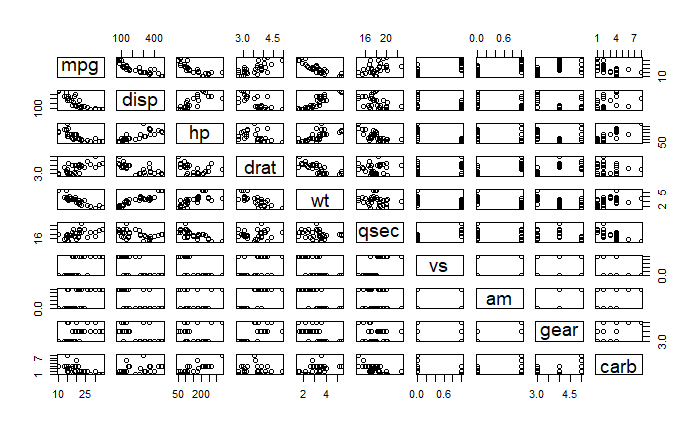

```r
pairs(~mpg+disp+hp+drat+wt+qsec+vs+am+gear+carb, data=mtcars)
```

The scatterplot matrix provides a visual examination of potential relationships between variables in the dataset.

# Linear Regression Models

```r
# Simple linear regression model
model_simple <- lm(mpg ~ am, data = mtcars)

# Multiple linear regression model
model_multiple <- lm(mpg ~ am + disp + hp + drat + wt + qsec + vs + gear + carb, data = mtcars)

summary(model_simple)
```

```
Call:
lm(formula = mpg ~ am, data = mtcars)

Residuals:
    Min      1Q  Median      3Q     Max
-9.3923 -3.0923 -0.2974  3.2439  9.5077

Coefficients:
            Estimate Std. Error t value Pr(>|t|)
(Intercept)   17.147      1.125  15.247 1.13e-15 ***
am             7.245      1.764   4.106 0.000285 ***
---
Signif. codes:  0 ‘***’ 0.001 ‘**’ 0.01 ‘*’ 0.05 ‘.’ 0.1 ‘ ’ 1

Residual standard error: 4.902 on 30 degrees of freedom
Multiple R-squared:  0.3598,    Adjusted R-squared:  0.3385
F-statistic: 16.86 on 1 and 30 DF,  p-value: 0.000285
```

```r
summary(model_multiple)
```

```
Call:
lm(formula = mpg ~ am + disp + hp + drat + wt + qsec + vs + gear +
    carb, data = mtcars)

Residuals:
    Min      1Q  Median      3Q     Max
-3.4286 -1.5908 -0.0412  1.2120  4.5961

Coefficients:
            Estimate Std. Error t value Pr(>|t|)
(Intercept) 10.96007   13.53030   0.810   0.4266
am           2.57743    1.94035   1.328   0.1977
disp         0.01283    0.01682   0.763   0.4538
hp          -0.02191    0.02091  -1.048   0.3062
drat         0.83520    1.53625   0.544   0.5921
wt          -3.69251    1.83954  -2.007   0.0572 .
qsec         0.84244    0.68678   1.227   0.2329
vs           0.38975    1.94800   0.200   0.8433
gear         0.71155    1.36562   0.521   0.6075
carb        -0.21958    0.78856  -0.278   0.7833
---
Signif. codes:  0 ‘***’ 0.001 ‘**’ 0.01 ‘*’ 0.05 ‘.’ 0.1 ‘ ’ 1

Residual standard error: 2.59 on 22 degrees of freedom
Multiple R-squared:  0.8689,    Adjusted R-squared:  0.8153
F-statistic: 16.21 on 9 and 22 DF,  p-value: 9.031e-08
```

The linear regression models help us understand the relationship between transmission type and mpg, considering other variables as well.

# Interpretation

```r
# Extract coefficients
coefficients_simple <- coef(model_simple)
coefficients_multiple <- coef(model_multiple)

# Calculate differences in mpg between transmission types
mpg_difference_simple <- coefficients_simple[2]
mpg_difference_multiple <- coefficients_multiple['am']

mpg_difference_simple
```

```
      am
7.244939
```

```r
mpg_difference_multiple
```

```
      am
2.577428
```

Based on the analysis:

- The simple linear regression model suggests that manual transmissions have approximately 7.24 mpg higher than automatic transmissions.
- However, in the multiple linear regression model, the difference in mpg between automatic and manual transmissions decreases to approximately 2.58 mpg.
- Both models indicate that manual transmissions tend to have higher mpg compared to automatic transmissions, but the exact difference varies depending on whether other variables are considered.

# Conclusion

### Model Diagnostics

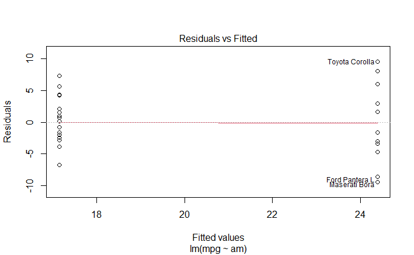

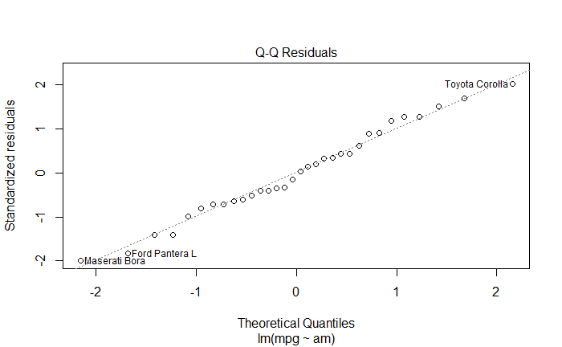

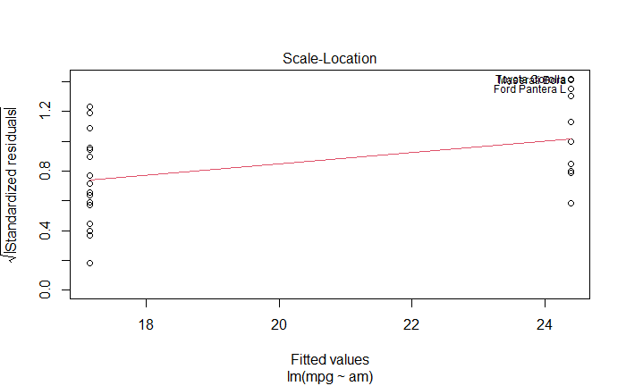

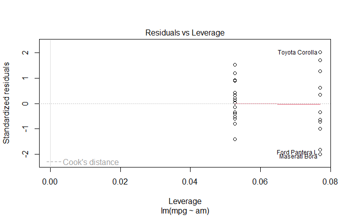

```r
plot(model_simple)
```

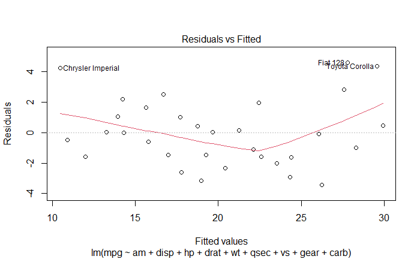

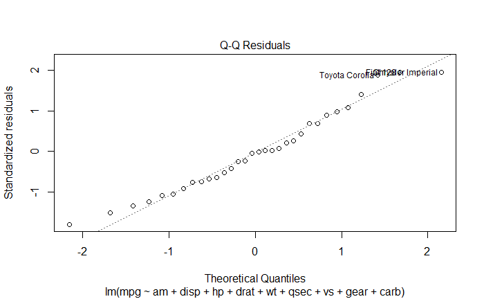

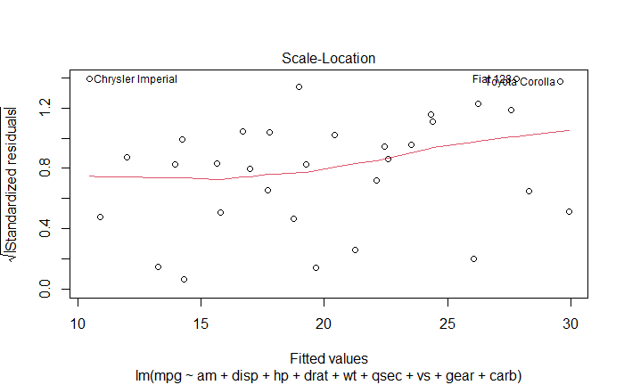

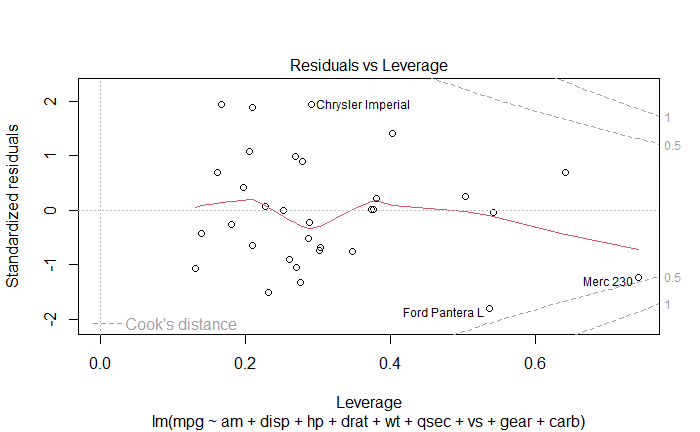

```r
plot(model_multiple)
```